# Intro to Data Science HW 7

##### Copyright Jeffrey Stanton, Jeffrey Saltz, and Jasmina Tacheva

```r
# Enter your name here: Patrick Walsh
```

### Attribution statement: (choose only one and delete the rest)

```r
# 1. I did this homework by myself, with help from the book and the professor.
```

The chapter on **linear models** (“Lining Up Our Models”) introduces **linear predictive modeling** using the tool known as **multiple regression**. The term “multiple regression” has an odd history, dating back to an early scientific observation of a phenomenon called **“regression to the mean.”** These days, multiple regression is just an interesting name for using **linear modeling** to assess the **connection between one or more predictor variables and an outcome variable**.

In this exercise, you will **predict Ozone air levels from three predictors**.

1. We will be using the **airquality** data set available in R. Copy it into a dataframe called **air** and use the appropriate functions to **summarize the data**.

```r
library(tidyverse)
air <- data.frame(airquality)
glimpse(air)
```

```
## Rows: 153
## Columns: 6
## $ Ozone   <int> 41, 36, 12, 18, NA, 28, 23, 19, 8, NA, 7, 16, 11, 14, 18, 14, …
## $ Solar.R <int> 190, 118, 149, 313, NA, NA, 299, 99, 19, 194, NA, 256, 290, 27…
## $ Wind    <dbl> 7.4, 8.0, 12.6, 11.5, 14.3, 14.9, 8.6, 13.8, 20.1, 8.6, 6.9, 9…
## $ Temp    <int> 67, 72, 74, 62, 56, 66, 65, 59, 61, 69, 74, 69, 66, 68, 58, 64…
## $ Month   <int> 5, 5, 5, 5, 5, 5, 5, 5, 5, 5, 5, 5, 5, 5, 5, 5, 5, 5, 5, 5, 5,…
## $ Day     <int> 1, 2, 3, 4, 5, 6, 7, 8, 9, 10, 11, 12, 13, 14, 15, 16, 17, 18,…
```

2. In the analysis that follows, **Ozone** will be considered as the **outcome variable**, and **Solar.R**, **Wind**, and **Temp** as the **predictors**. Add a comment to briefly explain the outcome and predictor variables in the dataframe using **?airquality**.

```r
# Ozone: Mean ozone in parts per billion
# Solar.R: Solar radiation in Langleys (frequency band)
# Wind: Average wind speed in miles per hour
# Temp: Maximum daily temperature in degrees Fahrenheit
?airquality
```

```
## starting httpd help server ... done
```

3. Inspect the outcome and predictor variables – are there any missing values? Show the code you used to check for that.

```r
# The outcome variable Ozone has missing values
# The predictor variable Solar.R has missing values
anyNA(air$Ozone)
```

```
## [1] TRUE
```

```r
anyNA(air$Solar.R)
```

```
## [1] TRUE
```

```r
anyNA(air$Wind)
```

```
## [1] FALSE
```

```r
anyNA(air$Temp)
```

```
## [1] FALSE
```

4. Use the **na_interpolation()** function from the **imputeTS package** (remember this was used in a previous HW) to fill in the missing values in each of the 4 columns. Make sure there are no more missing values using the commands from Step C.

```r
#install.packages("imputeTS")
library(imputeTS)
air$Ozone <- na_interpolation(air$Ozone)
air$Solar.R <- na_interpolation(air$Solar.R)

anyNA(air$Ozone)
```

```
## [1] FALSE
```

```r
anyNA(air$Solar.R)
```

```
## [1] FALSE
```

```r
anyNA(air$Wind)
```

```
## [1] FALSE
```

```r
anyNA(air$Temp)
```

```
## [1] FALSE
```

5. Create **3 bivariate scatterplots (X-Y) plots** (using ggplot), for each of the predictors with the outcome. **Hint:** In each case, put **Ozone on the Y-axis**, and a **predictor on the X-axis**. Add a comment to each, describing the plot and explaining whether there appears to be a **linear relationship** between the outcome variable and the respective predictor.

```r
library(ggplot2)
```

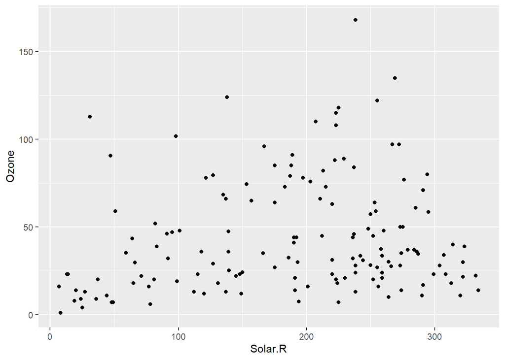

```r
# There appears to be a linear relationships between Solar.R and Ozone where
# Ozone increases a tiny amount as Solar.R increases (positive correlation)
ggplot(air, aes(x=Solar.R, y=Ozone)) +
    geom_point()
```

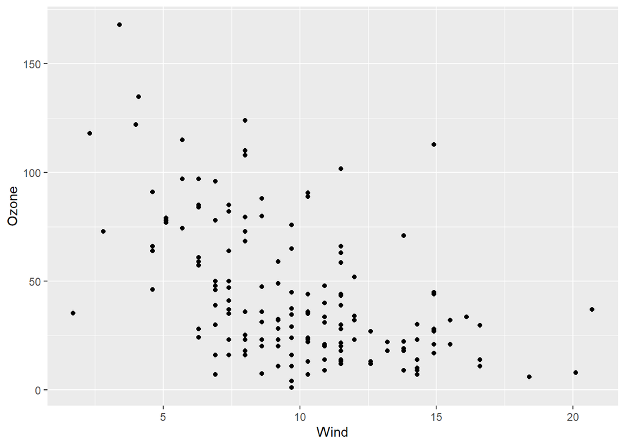

```r
# There appears to be a linear relationship between Wind and Ozone where
# Ozone decreases as Wind increases (negative correlation)
ggplot(air, aes(x=Wind, y=Ozone)) +
    geom_point()
```

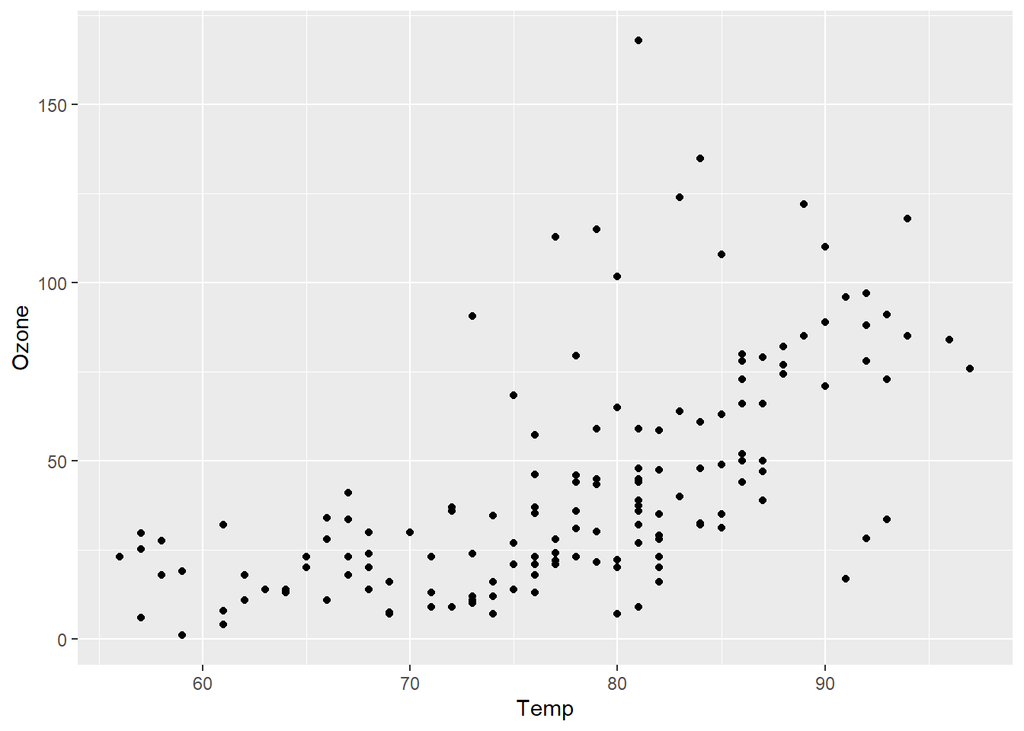

```r
# There appears to be a linear relationships between Temp and Ozone where
# Ozone increases as Temp increases (positive correlation)
ggplot(air, aes(x=Temp, y=Ozone)) +
    geom_point()
```

6. Next, create a **simple regression model** predicting **Ozone based on Wind**, using the **lm( )** command. In a comment, report the **coefficient** (aka **slope** or **beta weight**) of **Wind** in the regression output and, **if it is statistically significant**, **interpret it** with respect to **Ozone**. Report the **adjusted R-squared** of the model and try to explain what it means.

```r
# The coefficient of Wind is -4.5925. The p-value is less than 0.05, so it is statistically significant.
# The coefficient of Wind means that as Wind increases by 1, the value for Ozone decreases by -4.5925.
# This shows a negative correlation between Wind and Ozone.
# The Adjusted R-squared is 0.2527, which means that ~25.3% of the change in Ozone can be explained by a
# change in Wind.
lm_simple_regression <- lm(data=air, Ozone ~ Wind)
summary(lm_simple_regression)
```

```
##
## Call:
## lm(formula = Ozone ~ Wind, data = air)
##
## Residuals:
##     Min      1Q  Median      3Q     Max
## -50.332 -18.332  -4.155  14.163  94.594
##
## Coefficients:
##             Estimate Std. Error t value Pr(>|t|)
## (Intercept)  89.0205     6.6991  13.288  < 2e-16 ***
## Wind         -4.5925     0.6345  -7.238 2.15e-11 ***
## ---
## Signif. codes:  0 '***' 0.001 '**' 0.01 '*' 0.05 '.' 0.1 ' ' 1
##
## Residual standard error: 27.56 on 151 degrees of freedom
## Multiple R-squared:  0.2576, Adjusted R-squared:  0.2527
## F-statistic: 52.39 on 1 and 151 DF,  p-value: 2.148e-11
```

7. Create a **multiple regression model** predicting **Ozone** based on **Solar.R**, **Wind**, and **Temp**.  
   **Make sure to include all three predictors in one model – NOT three different models each with one predictor.**

```r
lm_multiple_regression <- lm(data=air, Ozone ~ Solar.R + Wind + Temp)
summary(lm_multiple_regression)
```

```
##
## Call:
## lm(formula = Ozone ~ Solar.R + Wind + Temp, data = air)
##
## Residuals:
##     Min      1Q  Median      3Q     Max
## -39.651 -15.622  -4.981  12.422 101.411
##
## Coefficients:
##              Estimate Std. Error t value Pr(>|t|)
## (Intercept) -52.16596   21.90933  -2.381   0.0185 *
## Solar.R       0.01654    0.02272   0.728   0.4678
## Wind         -2.69669    0.63085  -4.275 3.40e-05 ***
## Temp          1.53072    0.24115   6.348 2.49e-09 ***
## ---
## Signif. codes:  0 '***' 0.001 '**' 0.01 '*' 0.05 '.' 0.1 ' ' 1
##
## Residual standard error: 24.26 on 149 degrees of freedom
## Multiple R-squared:  0.4321, Adjusted R-squared:  0.4207
## F-statistic: 37.79 on 3 and 149 DF,  p-value: < 2.2e-16
```

8. Report the **adjusted R-Squared** in a comment – how does it compare to the adjusted R-squared from Step F? Is this better or worse? Which of the predictors are **statistically significant** in the model? In a comment, report the coefficient of each predictor that is statistically significant. Do not report the coefficients for predictors that are not significant.

```r
# The Adjusted R-squared is 0.4207 for this multiple regression model, as opposed to 0.2527 for the simple regression model.
# This is better because a higher adjusted R-squared value means we can account for more of the change in Ozone using
# multiple variables than we were able to account for using only 1 variable.
# Wind and Temp are statistically significant since their p-values are less than 0.05, but Solar.R is not statistically significant
# since its p-value is more than 0.05.
# The coefficient for Wind is -2.69669. This means that as Wind increases by 1, Ozone will decrease by -2.69669.
# The coefficient for Temp is 1.53072. This means that as Temp increases by 1, Ozone will increase by 1.53072.
```

1. Create a one-row data frame like this:

```r
predDF <- data.frame(Solar.R=290, Wind=13, Temp=61)
```

and use it with the **predict( )** function to predict the **expected value of Ozone**:

```r
predict(lm_multiple_regression, predDF)
```

```
##       1
## 10.9464
```

10. Create an additional **multiple regression model**, with **Temp** as the **outcome variable**, and the other **3 variables** as the **predictors**.

Review the quality of the model by commenting on its **adjusted R-Squared**.

```r
# The Adjusted R-squared is 0.403, meaning that ~40% of the change in Temp can be explained by a change in Ozone,
# Solar.R, and Wind. All coefficients are statistically significant.
lm_multiple_regression_temp <- lm(data=air, Temp ~ Ozone + Solar.R + Wind)
summary(lm_multiple_regression_temp)
```

```
##
## Call:
## lm(formula = Temp ~ Ozone + Solar.R + Wind, data = air)
##
## Residuals:
##     Min      1Q  Median      3Q     Max
## -18.831  -4.802   1.174   4.880  18.004
##
## Coefficients:
##              Estimate Std. Error t value Pr(>|t|)
## (Intercept) 74.693222   2.796787  26.707  < 2e-16 ***
## Ozone        0.139055   0.021907   6.348 2.49e-09 ***
## Solar.R      0.015751   0.006737   2.338  0.02072 *
## Wind        -0.580176   0.195774  -2.963  0.00354 **
## ---
## Signif. codes:  0 '***' 0.001 '**' 0.01 '*' 0.05 '.' 0.1 ' ' 1
##
## Residual standard error: 7.313 on 149 degrees of freedom
## Multiple R-squared:  0.4148, Adjusted R-squared:  0.403
## F-statistic: 35.21 on 3 and 149 DF,  p-value: < 2.2e-16
```